# Assignment 3 - Question 2

## Question 2

**Taken from Albert (2007). Normal linear regression.**

Dobson (2001) describes a birthweight regression study. One is interested in predicting a baby’s birthweight (in grams) based on the gestational age (in weeks) and the gender of the baby. The data is presented in the file *birthweight.txt*. In the standard linear regression model, we assume that
$$\text{Birthweight (i)} = \beta_{0} + \beta_{1}\,AGE\,(i) + \beta_{2}\,GENDER\,(i) + e(i)$$
where the *e(i)’s* are independent and Normally distributed random variables with mean **0** and variance $\sigma^{2}$.

##### (a) Use the R function lm to fit this model by Least-Squares. From the output, assess if the effects AGE and GENDER are significant, and if they are significant, describe the effects of each covariate on birthweight.

```r
fit <- lm(weight ~ age + gender, data = birthweight, model = TRUE, x=TRUE,y=TRUE)
summary(fit)
```

```
Call:
lm(formula = weight ~ age + gender, data = birthweight, model = TRUE,
    x = TRUE, y = TRUE)

Residuals:
    Min      1Q  Median      3Q     Max
-258.65 -155.48  -36.17  164.00  463.62

Coefficients:
             Estimate Std. Error t value Pr(>|t|)
(Intercept)   -924.94     896.09  -1.032  0.31373
age            103.02      23.32   4.417  0.00024 ***
genderFemale  -121.25      84.97  -1.427  0.16827
---
Signif. codes:  0 ‘***’ 0.001 ‘**’ 0.01 ‘*’ 0.05 ‘.’ 0.1 ‘ ’ 1

Residual standard error: 208.1 on 21 degrees of freedom
Multiple R-squared:  0.5032,    Adjusted R-squared:  0.4558
F-statistic: 10.63 on 2 and 21 DF,  p-value: 0.0006461
```

From the output of the linear model we can see that age is the only covariate that significantly effects birthweight ($\alpha = 0.05$). It has a positive effect on birthweight - i.e. as age increases, so does birthweight. Gender - which is not found to have a significant impact on birthweight - negatively effects birthweight if the child is female; it effects bw positively if the child is male. The value of the intercept is given as $\approx -924.94$.

##### (b) Suppose a uniform prior is placed on the regression parameters $\beta$ = ($\beta_{0}$, $\beta_{1}$, $\beta_{2}$). Use the LearnBayes package in R (blinreg command) to simulate an MC sample of **5000** draws from the joint posterior distribution of ($\beta$, $\sigma^{2}$). From the simulated sample, compute posterior means and standard deviations of $\beta_{1}$ and $\beta_{2}$. Compare the results with the LS estimates obtained in **(a)**.

```r
theta.sample <- blinreg(fit$y,fit$x,5000)
sumresids <- sum(fit$residual^2)
shape <- fit$df.residual/2
rate <- sumresids/2
sigma2 <- rigamma(1,shape,rate)
MSE <-  sum(fit$residuals^2)/fit$df.residual
vbeta <- vcov(fit)/MSE
beta <- rmnorm(1,mean=fit$coef,varcov=vbeta*sigma2)
```

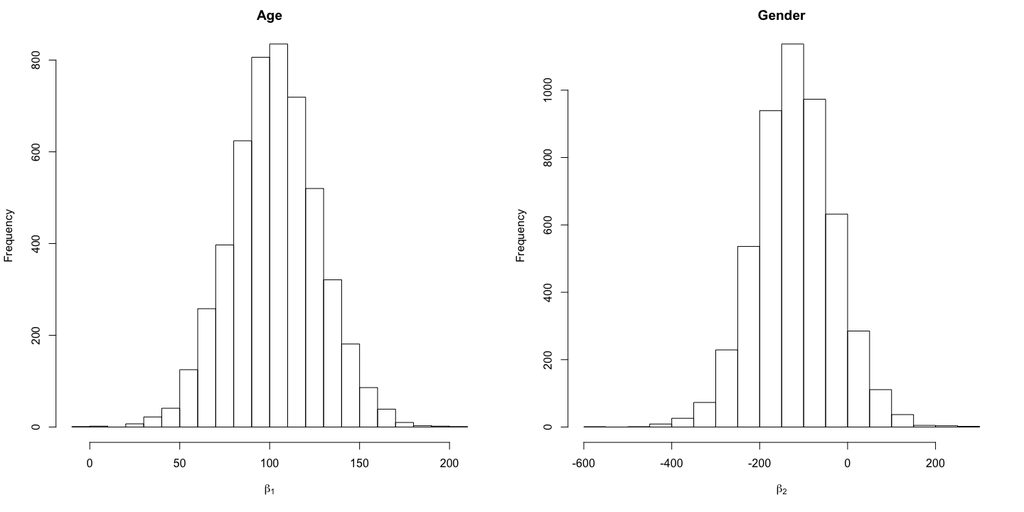

```r
par(mfrow=c(1,2))
hist(theta.sample$beta[,2],main="Age",xlab=expression(beta[1]), 30)
hist(theta.sample$beta[,3],main="Gender", xlab=expression(beta[2]),30)
```

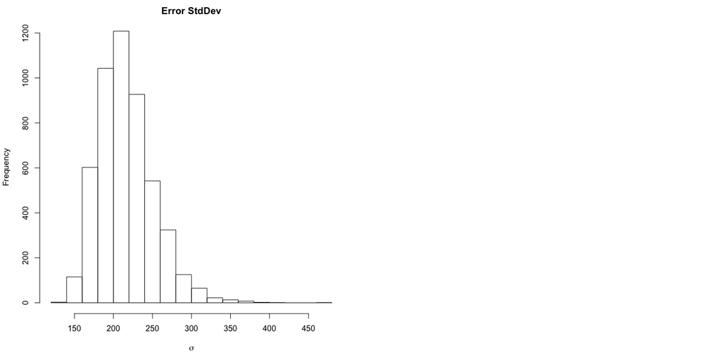

```r
hist(theta.sample$sigma,main="Error StdDev", xlab=expression(sigma))
```

```r
# CIs for the Beta coefficients
apply(theta.sample$beta,2,quantile,c(.05,.5,.95))
```

```
    X(Intercept)      Xage XgenderFemale
5%    -2478.1108  62.50355     -265.1744
50%    -907.2544 102.49836     -119.5783
95%     639.0429 143.29506       29.4658
```

```r
# CIs for sigma
quantile(theta.sample$sigma,c(.05,.5,.95))
```

```
      5%      50%      95%
166.5927 211.9257 278.9199
```

Here we are given values for the Intercept, Age coefficient and Gender coefficient of approximately $-907.2544, 102.49836$ and $-119.5783$ respectively, which are pretty close to the values obtained using the method in part (a).

##### (c) Repeat part **(b)** using WinBUGS. Compare the results with the LS estimates obtained in **(a)** and MC sampling in part **(b)**.

```r
require(R2OpenBUGS)
require(coda)
#define the model
birthweightmodel <- function(){
  for (i in 1:n) {
    mu[i] <- beta0 + beta1*x1[i] + beta2*x2[i]
    yi[i] ~ dnorm(mu[i],tau)
  }
  beta0 ~  dflat()
  sigma ~ dunif(0.01, 100)
  tau <- 1/(sigma*sigma)
  beta1 ~  dflat()
  beta2 ~  dflat()
}
# write the model code out to a file
write.model(birthweightmodel, "birthweightmodel.txt")
model.file1 = paste(getwd(),"birthweightmodel.txt", sep="/")
#prepare the data for input into OpenBUGS
x1 <- fit$model[,2]
x2 <- as.integer(unclass(fit$model[,3]))
yi <- fit$model[,1]
n <- 24
data <- list("x1","x2","yi","n")
#initialization of variables
inits <- function(){
  list(beta0=0, beta1=1,beta2=1,sigma=1)
}
WINE="/opt/local/bin/wine"
WINEPATH="/opt/local/bin/winepath"
OpenBUGS.pgm="/Users/benjamin/Applications/wine/drive_c/ProgramFiles/OpenBUGS/OpenBUGS323/OpenBUGS.exe"
#these are the parameters to save
parameters = c("beta0", "beta1","beta2")
#run the model
birthweight.sim <- bugs(data,
                    inits,
                    model.file = model.file1,
                    parameters=parameters,
                    n.chains = 5,
                    n.iter = 10000,
                    OpenBUGS.pgm=OpenBUGS.pgm,
                    WINE=WINE,
                    WINEPATH=WINEPATH,
                    useWINE=T,
                    codaPkg = T,
                    working.directory = getwd(),
                    debug = F)
```

```
err:ole:CoReleaseMarshalData IMarshal::ReleaseMarshalData failed with error 0x8001011d
```

```r
samples <- read.openbugs()
```

[output not shown]

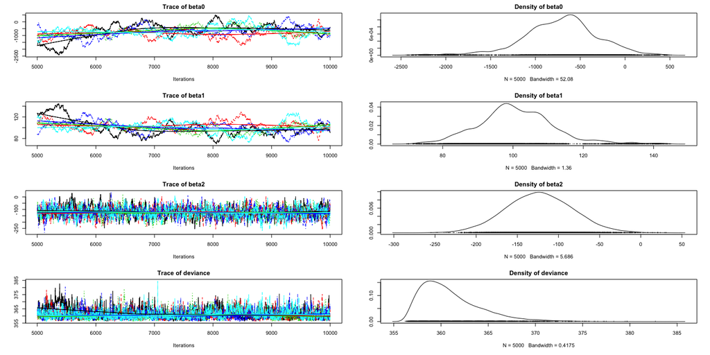

```r
plot(samples)
```

```r
summary(samples)
```

```
Iterations = 5001:10000
Thinning interval = 1
Number of chains = 5
Sample size per chain = 5000

1. Empirical mean and standard deviation for each variable,
   plus standard error of the mean:

           Mean      SD Naive SE Time-series SE
beta0    -718.8 418.164  2.64470        75.9269
beta1     100.9  10.816  0.06841         1.9390
beta2    -123.1  40.655  0.25712         1.1250
deviance  361.0   3.191  0.02018         0.1361

2. Quantiles for each variable:

             2.5%     25%    50%     75%  97.5%
beta0    -1660.00 -966.12 -692.7 -467.17  61.33
beta1       80.98   94.27  100.3  107.30 125.40
beta2     -202.60 -150.80 -123.5  -95.72 -42.15
deviance   356.80  358.60  360.3  362.60 369.00
```